# Identifying Frequently Purchased Groceries with Association Rules

**Association Rules** learning is the core behind many online recommendation engines such as online stores such movies, musics, games services, and fashion retails…etc. For example, if site users database shows that sites visitors tend to watch animation shows, then perhaps more kids shows should pop up on the recommendation list.

Many groceries companies also use this technique to improve their inventory allocation to maximize customer’s spending in their stores. For example, if transactions database showing a trend that shoppers tend to buy coffee and creamers together, perhaps, inventory managers should place coffee and creamers in the same aisle to maximize customers’ convenience thus increase their spending.

In this tutorial, we will employ **Market Basket Analysis** technique on groceries transactions data to identify consumers’ shopping behaviors.

#### **About the data set:**

The groceries data set that we will be using is collected from a real groceries store. It contains 9835 transactions, about 327 transactions were made in the span of one month (9835 / 327 = 30 days). This groceries data set is bundled in the *arules* R package.

#### **Step 1: Load data set**

We will be using the *arules* package, so we first need to install and load it into memory.

```r
#install.packages('arules')
library(arules)
```

Now we need to load the dataset files in csv format. **NOTE:** The approach for loading transactions data is different than loading normal data frame with predetermined number of features. Each row in transactions dataset has different number of items, thus we cannot load transactions data into a normal data frame. The reason is when we use the normal *read.csv(…)* functions, R will assume the dataset only has a fixed number of features (columns), it does this by looking at the first row of the dataset. In our case, the first row contains 4 items, thus R will assume the rest of the dataset’s rows has only 4 features (columns) and it will cut off the rest of items in rows that have more than 4 items.

We will instead use another similar function implemented in the *arules* package which allow us to load Groceries dataset into a *sparse matrix*.

```r
groceries <- read.transactions("../Datasets/groceries.csv", sep = ",")
summary(groceries)
```

```
transactions as itemMatrix in sparse format with
 9835 rows (elements/itemsets/transactions) and
 169 columns (items) and a density of 0.02609146

most frequent items:
      whole milk other vegetables       rolls/buns             soda           yogurt          (Other)
            2513             1903             1809             1715             1372            34055

element (itemset/transaction) length distribution:
sizes
   1    2    3    4    5    6    7    8    9   10   11   12   13   14   15   16   17   18   19   20   21   22   23   24
2159 1643 1299 1005  855  645  545  438  350  246  182  117   78   77   55   46   29   14   14    9   11    4    6    1
  26   27   28   29   32
   1    1    1    3    1

   Min. 1st Qu.  Median    Mean 3rd Qu.    Max.
  1.000   2.000   3.000   4.409   6.000  32.000

includes extended item information - examples:
            labels
1 abrasive cleaner
2 artif. sweetener
3   baby cosmetics
```

As we can see, in our case, a sparse matrix that represent the transactions dataset has 169 features (columns); each features is an item that appears in the dataset, thus there are 169 possible items in the dataset. Each row contains binary values which indicate whether or not each item (represented by the column names) appear in that transaction. For example, the second transaction of the dataset has three items: *tropical fruit, yogurt,* and *coffee*, thus the second row of the sparse matrix will has values ‘1’ for columns *tropical fruit, yogurt,* and *coffee*, the rest of the columns will has values ‘0’.

A few insight can also be extracted by looking at the summary of the data above. For example, there are 2513 ‘whole milk’ , and 1903 ‘other vegetables’ transactions. There are 2159 transactions where 1 item was bought, and 1 transactions where 32 items were bought. Obviously, the least item bought is 1 and the most items bought is 32, and the average number of items bought is 4.4 items.

#### **Step 2: Explore and Prepare the data**

Let’s take a peek at the data matrix. We can use *inspect(..)* function from the *arules* package to take a look at the sparse matrix.

```r
inspect(groceries[1:7])
```

```
    items
[1] {citrus fruit,margarine,ready soups,semi-finished bread}
[2] {coffee,tropical fruit,yogurt}
[3] {whole milk}
[4] {cream cheese,meat spreads,pip fruit,yogurt}
[5] {condensed milk,long life bakery product,other vegetables,whole milk}
[6] {abrasive cleaner,butter,rice,whole milk,yogurt}
[7] {rolls/buns}
```

We can also extract the frequency of items which represented by columns:

```r
itemFrequency(groceries[,1:10])
```

```
abrasive cleaner artif. sweetener   baby cosmetics        baby food             bags    baking powder bathroom cleaner
    0.0035587189     0.0032536858     0.0006100661     0.0001016777     0.0004067107     0.0176919166     0.0027452974
            beef          berries        beverages
    0.0524656838     0.0332486019     0.0260294865
```

==> this output show the frequencies of the first 10 items (ordered alphabetically) in the sparse matrix. As we can see, items such as “beef”, “berries”, and “beverages” are a lot more frequently bought compare to items such as “abrasive cleaner”, “baby food”, “bags”, and so on.

Plotting the items with their frequencies also helps us have a visual understanding of how often items are bought. The *arules* package also provides a convenient method to do so. Since, the number of items usually are very large depends on the datasets, plotting all of them in one plot is not a good idea; instead, we should only plot the items that have a frequency more than a threshold that we choose.

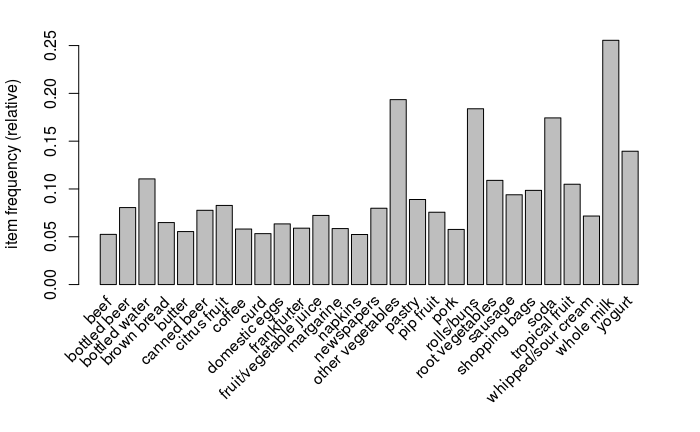

```r
# only items with frequency higher than the chosen support values will be plotted
itemFrequencyPlot(groceries, support=0.05)
```

We can also limit the number of the items to be plotted by specifying the parameter ‘topN’:

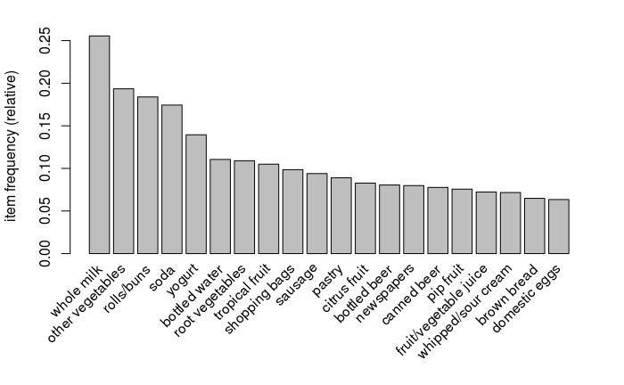

```r
itemFrequencyPlot(groceries, topN=20)
```

What can we say from this plot? Whole milk is bought the most frequent, this alone makes sense if we think about how often we bought milk compare to other items.

[figure not shown]

In addition, we can also draw an image of the sparse matrix using function *image()* implemented in *arules* package.

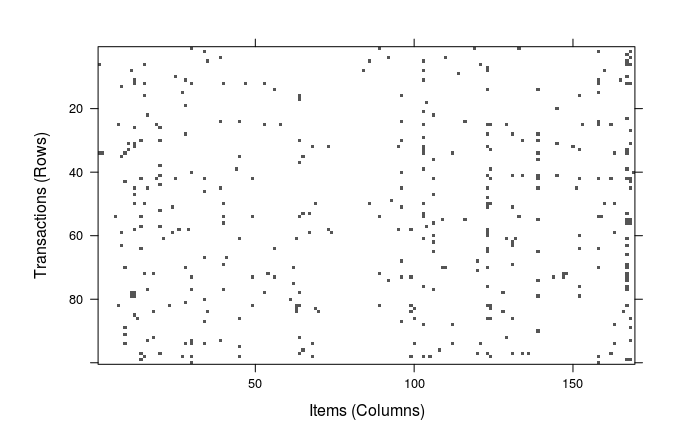

```r
image(groceries[1:100])
```

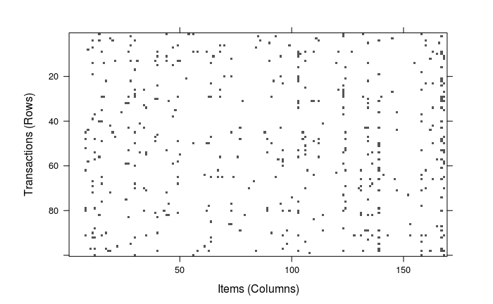

```r
image(sample(groceries, 100))
```

Each black dot in the image above represent the appearance of an item in each transaction. We observe that there are some consecutive transactions in which a common item were bought. The more an item appear in a vertical line, the more often that item was bought.

#### **Step 3: Train a Model using the Dataset**

Once we satisfied with the general understanding of data, we can now go ahead and train a model to identify associations between groceries items. We will do this with the help of the Apriori algorithm implemented in the *arules* package.

The general usage of *apriori(..)* function can is as followed: `apriori(data, parameter = NULL, appearance = NULL, control = NULL)`. The `parameter` argument can be used to set the minimum support, confidence, maximum of items, and maximal time checking a subset. Let go with the default `parameter` first with support=0.1, confidence=0.8, maximum of 10 items, and maximal time for subset checking of 5 seconds:

```r
apriori(groceries)
```

```
Apriori

Parameter specification:
 confidence minval smax arem  aval originalSupport maxtime support minlen maxlen target   ext
        0.8    0.1    1 none FALSE            TRUE       5     0.1      1     10  rules FALSE

Algorithmic control:
 filter tree heap memopt load sort verbose
    0.1 TRUE TRUE  FALSE TRUE    2    TRUE

Absolute minimum support count: 983

set item appearances ...[0 item(s)] done [0.00s].
set transactions ...[169 item(s), 9835 transaction(s)] done [0.00s].
sorting and recoding items ... [8 item(s)] done [0.00s].
creating transaction tree ... done [0.00s].
checking subsets of size 1 2 done [0.00s].
writing ... [0 rule(s)] done [0.00s].
creating S4 object  ... done [0.00s].
set of 0 rules
```

```r
groceriesRules <- apriori(groceries, parameter = list(support=0.006, confidence=0.25, minlen=2))
```

```
Apriori

Parameter specification:
 confidence minval smax arem  aval originalSupport maxtime support minlen maxlen target   ext
       0.25    0.1    1 none FALSE            TRUE       5   0.006      2     10  rules FALSE

Algorithmic control:
 filter tree heap memopt load sort verbose
    0.1 TRUE TRUE  FALSE TRUE    2    TRUE

Absolute minimum support count: 59

set item appearances ...[0 item(s)] done [0.00s].
set transactions ...[169 item(s), 9835 transaction(s)] done [0.00s].
sorting and recoding items ... [109 item(s)] done [0.00s].
creating transaction tree ... done [0.00s].
checking subsets of size 1 2 3 4 done [0.00s].
writing ... [463 rule(s)] done [0.00s].
creating S4 object  ... done [0.00s].
```

```r
groceriesRules
```

```
set of 463 rules
```

==> As we can see by adjusting the parameters such as minimum support, confidence levels, and number of items, we have dramatically increased the number of association rules discovered by the algorithm. Whether these rules are useful, we need to look deeper into them.

#### **Step 4: Evaluate Model performance**

Let’s take a look at the summary of the rules object created:

```r
summary(groceriesRules)
```

```
set of 463 rules

rule length distribution (lhs + rhs):sizes
  2   3   4
150 297  16

   Min. 1st Qu.  Median    Mean 3rd Qu.    Max.
  2.000   2.000   3.000   2.711   3.000   4.000

summary of quality measures:
    support           confidence          lift
 Min.   :0.006101   Min.   :0.2500   Min.   :0.9932
 1st Qu.:0.007117   1st Qu.:0.2971   1st Qu.:1.6229
 Median :0.008744   Median :0.3554   Median :1.9332
 Mean   :0.011539   Mean   :0.3786   Mean   :2.0351
 3rd Qu.:0.012303   3rd Qu.:0.4495   3rd Qu.:2.3565
 Max.   :0.074835   Max.   :0.6600   Max.   :3.9565

mining info:
      data ntransactions support confidence
 groceries          9835   0.006       0.25
```

What can we say about this summary? There are 150 rules with 2 associated items, 297 rules with 3 items, and 16 rules with 4 items. The statistic of support, confidence, and lift levels also shown. The most interesting of these three is the lift statistic. What lift represents is the ratio of the confidence level of an item and its support level. The higher the lift statistic, the stronger the association rule between items in concern. For example, if the frequency of milk is 0.1 out of all transactions and the frequency milk appears whenever bread is bought is 0.5, then support(milk) = 0.1, confidence(milk->bread) = 0.5, therefore its lift factor is 0.5/0.1 = 5. As we can see, **the higher the lift factor of an item given another item, the stronger the association between these two items**!!

We can also look at a few specific rules in the `groceriesRules` object using the `inspect(..)` function.

```r
inspect(groceriesRules[1:3])
```

```
    lhs             rhs               support     confidence lift
[1] {pot plants} => {whole milk}      0.006914082 0.4000000  1.565460
[2] {pasta}      => {whole milk}      0.006100661 0.4054054  1.586614
[3] {herbs}      => {root vegetables} 0.007015760 0.4312500  3.956477
```

#### **Step 5: Improve model performance**

##### Sorting the rules

Going through all 463 rules might be a take a lot of time and effort especially when they are unordered. We can order the rules using the *arules*’s function `sort(..)` and specifying by which statistic do we want to sort the rules by:

```r
inspect(sort(groceriesRules, by = "lift")[1:10])
```

```
     lhs                                             rhs                  support     confidence lift
[1]  {herbs}                                      => {root vegetables}    0.007015760 0.4312500  3.956477
[2]  {berries}                                    => {whipped/sour cream} 0.009049314 0.2721713  3.796886
[3]  {other vegetables,tropical fruit,whole milk} => {root vegetables}    0.007015760 0.4107143  3.768074
[4]  {beef,other vegetables}                      => {root vegetables}    0.007930859 0.4020619  3.688692
[5]  {other vegetables,tropical fruit}            => {pip fruit}          0.009456024 0.2634561  3.482649
[6]  {beef,whole milk}                            => {root vegetables}    0.008032537 0.3779904  3.467851
[7]  {other vegetables,pip fruit}                 => {tropical fruit}     0.009456024 0.3618677  3.448613
[8]  {pip fruit,yogurt}                           => {tropical fruit}     0.006405694 0.3559322  3.392048
[9]  {citrus fruit,other vegetables}              => {root vegetables}    0.010371124 0.3591549  3.295045
[10] {other vegetables,whole milk,yogurt}         => {tropical fruit}     0.007625826 0.3424658  3.263712
```

Here we have sorted the rules based on the highest value of lift factor. The rule with the highest lift factor turned out to be {herbs ==> root vegetables}, this could mean that customers who buy root vegetables are about 4 times more likely to buy some herbs too; why do you buy herbs and root vegetables together? Maybe to make some soup? Similarly, customers are 3.7 times more likely to buy some berries when they are buying whipped/sour cream. Have you ever eaten berries with whipped cream? If you have, then you probably know why these two items tend to appear in the same transactions.

##### Taking subsets of the rules

The *arules* package also provide a convenient way to list all the rules that contains a certain item of interest using `subset(..)`. Let say we are interested in all the rules that concern “whole milk”, we could list all these rules easily.

```r
berryRules <- subset(groceriesRules, subset = (lhs %in% "whole milk" | rhs %in% "whole milk") & lift > 3)
inspect(berryRules)
```

```
    lhs                                             rhs                support     confidence lift
[1] {beef,whole milk}                            => {root vegetables}  0.008032537 0.3779904  3.467851
[2] {root vegetables,tropical fruit,whole milk}  => {other vegetables} 0.007015760 0.5847458  3.022057
[3] {other vegetables,tropical fruit,whole milk} => {root vegetables}  0.007015760 0.4107143  3.768074
[4] {other vegetables,tropical fruit,whole milk} => {yogurt}           0.007625826 0.4464286  3.200164
[5] {other vegetables,whole milk,yogurt}         => {tropical fruit}   0.007625826 0.3424658  3.263712
[6] {other vegetables,whole milk,yogurt}         => {root vegetables}  0.007829181 0.3515982  3.225716
[7] {other vegetables,rolls/buns,whole milk}     => {root vegetables}  0.006202339 0.3465909  3.179778
```

What we see here is all the rules that contain “whole milk” which appears either in the left hand side or in the right hand side of the rules with the constraint that the lift factor has to be at least 3.000. We could do the same with the lift factor starting from 2.00 but that would result in a really long list considering how popular “whole milk” is in our transactions dataset. This will be left as an exercise for you readers.

[figure not shown]

##### Saving learned rules to files

It’s good to know that you can also save the rules learned by the algorithm to local files so that it’s easier to share your result to others. We can do this by calling the function `write`:

```r
write(groceriesRules, file = "groceriesRules.csv", sep=",", quote = TRUE, row.names = FALSE)
# we can also write this rules object back into a dataframe in case we want to process the data further by doing:
groceriesRulesDF <- as(groceriesRules, "data.frame")
```

#### Reference:

*Machine Learning with R*, by *Brett Lantz*